# Multiple Regression

Models with more than one predictor

Author

Affiliation

Daniela Palleschi

Humboldt-Universität zu Berlin

Published

July 1, 2023

# Learning Objectives

Today we will learn…

- what multiple regression is
- fit a model with multiple predictors
- learn to interpret interactions

# Set-up environment

```r
# suppress scientific notation
options(scipen=999)
```

## Packages

Run this in the Console:

```r
install.packages("devtools")
devtools::install_github("strengejacke/sjPlot")
```

Then copy this into your script:

```r
# load libraries
pacman::p_load(
  tidyverse,
  here,
  knitr,
  kableExtra,
  gt,
  broom,
  Rmisc,
  patchwork,
  sjPlot
)
```

## Data

```r
# read in data
df_crit_verb <- readr::read_csv(here::here("data/tidy_data_lifetime_pilot.csv"),
                               # for special characters
                               locale = readr::locale(encoding = "latin1")
                               ) |>
  mutate_if(is.character,as.factor) |> # all character variables as factor
  filter(type == "critical", # only critical trials
         px != "px3",
         region == "verb") |>
  droplevels()
```

# Resources

Chapters 6 and 7 in Winter (2019)

# 1 Review: Linear Regression

- let’s re-run our simple linear model: `fp ~ lifetime`

## 1.1 Set contrasts

Let’s stick to sum contrast coding (+/-0.5).

```r
# order factor levels
df_crit_verb$lifetime <- factor(df_crit_verb$lifetime, levels = c("living","dead"))
# or using the tidyverse
df_crit_verb <-
  df_crit_verb %>%
  mutate(lifetime = fct_relevel(lifetime, "living", "dead"))
```

```r
# set contrasts
contrasts(df_crit_verb$lifetime) <- c(-0.5,+0.5)
```

```r
contrasts(df_crit_verb$lifetime)
```

```
       [,1]
living -0.5
dead    0.5
```

## 1.2 Fit model

```r
# fit simple linear model
fit_fp_lifetime <- df_crit_verb %>%
  filter(fp > 0) %>%
  lm(fp ~ lifetime, data = .)
```

```r
# check our contrasts
coef(fit_fp_lifetime)
```

```
(Intercept)   lifetime1
  309.14208    31.70113
```

## 1.3 Lifetime Effect

- recall that we found a significant effect of `lifetime`
  - the `dead` conditions elicited longer first-pass reading times than the `living` conditions
- but we also had two tenses: the Present Perfect (`PP`) and the Simple Future (`SF`)
  - how can we also check for an effect of `tense`?

## 1.4 Another linear model

- we could run a second model with `tense` as the predictor instead of `lifetime`

```r
df_crit_verb <-
  df_crit_verb %>%
  mutate(tense = fct_relevel(tense, "PP", "SF"))
```

```r
contrasts(df_crit_verb$tense) <- c(-0.5,+0.5)
```

```r
contrasts(df_crit_verb$tense)
```

```
   [,1]
PP -0.5
SF  0.5
```

```r
# fit simple linear model
fit_fp_tense <-
  df_crit_verb %>%
  filter(fp > 0) %>%
  lm(fp ~ tense, data = .)
```

- what does the summary tell us?

```r
summary(fit_fp_tense)
```

```
Call:
lm(formula = fp ~ tense, data = .)

Residuals:
    Min      1Q  Median      3Q     Max
-232.75 -109.66  -28.57   61.84  768.43

Coefficients:
            Estimate Std. Error t value            Pr(>|t|)
(Intercept)  309.159      6.289  49.156 <0.0000000000000002 ***
tense1       -13.174     12.579  -1.047               0.295
---
Signif. codes:  0 '***' 0.001 '**' 0.01 '*' 0.05 '.' 0.1 ' ' 1

Residual standard error: 146.6 on 541 degrees of freedom
Multiple R-squared:  0.002024,  Adjusted R-squared:  0.0001789
F-statistic: 1.097 on 1 and 541 DF,  p-value: 0.2954
```

# 2 Multiple regression

- a simple linear model is essentially just modelling the mean
- so is multiple regression, but takes more conditions into account:

$$y = b_0 + b_1x + b_2x + ... + e$$

- the slope index ($b_1$, $b_2$) differentiates between predictors

$$fp = b_0 + (b_1\times lifetime) + (b_2\times tense) + ... + e$$

## 2.1 Adding another predictor

- in our experimental design we were interested in the effect of *lifetime* on the processing of two different *tenses*: the Present Perfect and Simple Future
  - in other words, we had two fixed factors: lifetime and tense
- multiple regression is not the same as running separate simple linear models, rather each coefficient becomes a *partial* regression coefficient

## 2.2 Fit model

- we can use `+` to indicate we have another fixed effect, and that we want to look at the **main effect** of this predictor

```r
# multiple regression
fit_fp <-
  df_crit_verb %>%
  filter(fp > 0) %>%
  lm(fp ~ lifetime + tense, data = .)
```

### 2.2.1 Model summary

```r
summary(fit_fp)
```

```
Call:
lm(formula = fp ~ lifetime + tense, data = .)

Residuals:
    Min      1Q  Median      3Q     Max
-235.28 -107.36  -27.75   58.72  784.02

Coefficients:
            Estimate Std. Error t value            Pr(>|t|)
(Intercept)  309.130      6.258  49.394 <0.0000000000000002 ***
lifetime1     31.537     12.518   2.519               0.012 *
tense1       -12.768     12.518  -1.020               0.308
---
Signif. codes:  0 '***' 0.001 '**' 0.01 '*' 0.05 '.' 0.1 ' ' 1

Residual standard error: 145.8 on 540 degrees of freedom
Multiple R-squared:  0.01362,   Adjusted R-squared:  0.009964
F-statistic: 3.727 on 2 and 540 DF,  p-value: 0.02468
```

## 2.3 Comparing summaries

```r
tidy(fit_fp_lifetime) %>% kable() %>% kable_styling()
```

Table 1: Coefficients for fit_fp_lifetime (fp ~ lifetime)

| term | estimate | std.error | statistic | p.value |
| --- | --- | --- | --- | --- |
| (Intercept) | 309.14208 | 6.258665 | 49.39425 | 0.0000000 |
| lifetime1 | 31.70113 | 12.517330 | 2.53258 | 0.0116043 |

```r
tidy(fit_fp_tense) %>% kable() %>% kable_styling()
```

Table 2: Coefficients for fit_fp_tense (fp ~ tense)

| term | estimate | std.error | statistic | p.value |
| --- | --- | --- | --- | --- |
| (Intercept) | 309.15914 | 6.289283 | 49.156500 | 0.0000000 |
| tense1 | -13.17437 | 12.578566 | -1.047366 | 0.2953983 |

```r
tidy(fit_fp) %>% kable() %>% kable_styling()
```

Table 3: Coefficients for fit_fp (fp ~ lifetime + tense)

| term | estimate | std.error | statistic | p.value |
| --- | --- | --- | --- | --- |
| (Intercept) | 309.13047 | 6.258442 | 49.394159 | 0.0000000 |
| lifetime1 | 31.53658 | 12.517903 | 2.519318 | 0.0120458 |
| tense1 | -12.76792 | 12.517903 | -1.019973 | 0.3081979 |

## 2.4 Partial regression coefficients

- in multiple regression, each predictor becomes a *partial* regression coefficient
  - the effect of one predictor while holding all other predictors constant

$$\begin{align}
fp &= 309.1 + (31.5\times lifetime) + (-12.8\times tense)\\
fp_{dead-PP} &= 309.1 + (31.5\times 0.5) + (-12.8\times -0.5)
\end{align}$$

## Exploring the model: fixed effects

- what were our coefficients?

```r
coef(fit_fp)
```

```
(Intercept)   lifetime1      tense1
  309.13047    31.53658   -12.76792
```

- what is the mean of `lifetime` coded as `-0.5` (`living`)?

```r
coef(fit_fp)['(Intercept)'] + coef(fit_fp)['lifetime1'] * -0.5
```

```
(Intercept)
   293.3622
```

- ignore the `(Intercept)` label here, `R` just takes the first label when performing an operation on 2 vectors
- what is the mean of `lifetime` coded as `+0.5` (`dead`)?

```r
coef(fit_fp)['(Intercept)'] + coef(fit_fp)['lifetime1'] * 0.5
```

```
(Intercept)
   324.8988
```

### 2.4.1 Exercise

- do the same for `tense`:
  - find the fitted value for `PP` and for `SF`

## 2.5 Exploring the model: predicting fp

Table 4: Coefficient estimates

| term | estimate | *0.5 |
| --- | --- | --- |
| (Intercept) | 309.1 | 154.6 |
| lifetime1 | 31.5 | 15.8 |
| tense1 | -12.8 | -6.4 |

Table 5: Fitted values per condition

| lifetime | tense | .fitted | fp | mean_diff |
| --- | --- | --- | --- | --- |
| living | PP | 299.7 | 294.3 | -5.5 |
| living | SF | 287.0 | 292.4 | 5.4 |
| dead | PP | 331.3 | 336.6 | 5.3 |
| dead | SF | 318.5 | 313.0 | -5.5 |

### 2.5.1 Calculating fitted values by hand

$$fp = b_0 + (b_1\times lifetime) + (b_2\times tense) + e$$

```r
# living-PP
coef(fit_fp)['(Intercept)'] +
  coef(fit_fp)['lifetime1'] * -0.5 + coef(fit_fp)['tense1'] * -0.5
```

```
(Intercept)
   299.7461
```

```r
# living-SF
coef(fit_fp)['(Intercept)'] +
  coef(fit_fp)['lifetime1'] * -0.5 + coef(fit_fp)['tense1'] * 0.5
```

```
(Intercept)
   286.9782
```

```r
# dead-PP
coef(fit_fp)['(Intercept)'] +
  coef(fit_fp)['lifetime1'] * 0.5 + coef(fit_fp)['tense1'] * -0.5
```

```
(Intercept)
   331.2827
```

```r
# dead-SF
coef(fit_fp)['(Intercept)'] +
  coef(fit_fp)['lifetime1'] * 0.5 + coef(fit_fp)['tense1'] * 0.5
```

```
(Intercept)
   318.5148
```

## Exploring the model: residuals

- recall that residuals = the difference between our *fitted* (model) values and our *observed* (data) values

```r
# what do our FITTED values look like?
head(fitted(fit_fp))
```

```
       1        2        3        4        5        6
299.7461 299.7461 331.2827 299.7461 318.5148 286.9782
```

```r
# what do our OBSERVED values look like?
head(df_crit_verb$fp)
```

```
[1] 175 413 960 231 407 319
```

```r
# what is the difference between the FITTED and OBSERVED values?
head(df_crit_verb$fp) - head(fitted(fit_fp))
```

```
         1          2          3          4          5          6
-124.74615  113.25385  628.71727  -68.74615   88.48520   32.02178
```

```r
# what are our RESIDUALS?
head(residuals(fit_fp))
```

```
         1          2          3          4          5          6
-124.74615  113.25385  628.71727  -68.74615   88.48520   32.02178
```

## 2.6 Plotting our effects

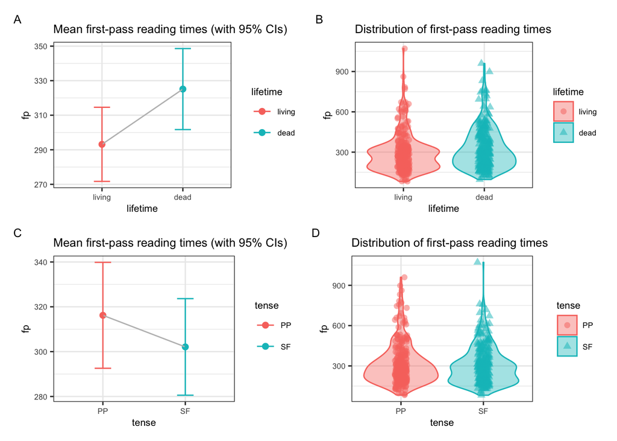

Figure 1: Plotting our two predictors

### 2.6.1 Plotting coefficients with `sjPlot`

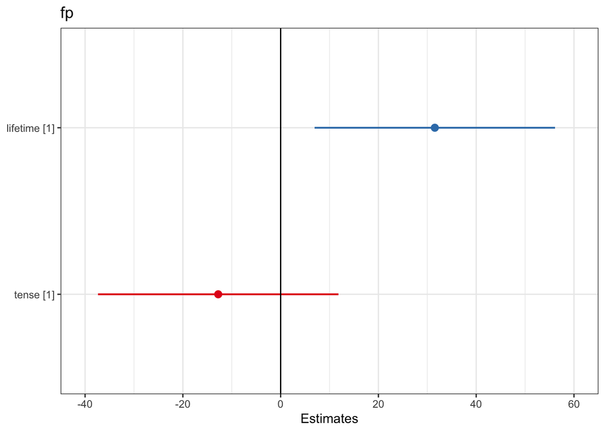

```r
plot_model(fit_fp) +
  geom_hline(yintercept=0) +
  theme_bw()
```

# 3 Interactions

- interactions are when the effect of a predictor on an outcome depends on another predictor
  - an example from McElreath (n.d.): plant growth cannot be predicted solely by sun exposure or water exposure, but rather the two
  - the influence of the sun is dependent on water, and vice versa
- the equation for multiple regression with an interaction effect is as follows:

$$y = b_0 + b_1x_1 + b_2x_2 + b_3(x_1*x_2) + e$$

- where $b_0, b_1, b_2$ equal the intercept, and the slopes ($b_1, b_2$) of two variables ($x_1, x_2$)
- the interaction ($b_3$) is the multiplication of $x_1$ and $x_2$

## 3.1 Fitting an interaction term to our model

```r
# multiple regression
fit_fp_inter <-
  df_crit_verb %>%
  filter(fp > 0) %>%
  lm(fp ~ lifetime*tense, data = .)
```

```r
summary(fit_fp_inter)
```

```
Call:
lm(formula = fp ~ lifetime * tense, data = .)

Residuals:
    Min      1Q  Median      3Q     Max
-240.62 -108.69  -27.62   56.20  778.65

Coefficients:
                 Estimate Std. Error t value            Pr(>|t|)
(Intercept)        309.06       6.26  49.367 <0.0000000000000002 ***
lifetime1           31.52      12.52   2.517              0.0121 *
tense1             -12.75      12.52  -1.018              0.3090
lifetime1:tense1   -21.69      25.04  -0.866              0.3868
---
Signif. codes:  0 '***' 0.001 '**' 0.01 '*' 0.05 '.' 0.1 ' ' 1

Residual standard error: 145.9 on 539 degrees of freedom
Multiple R-squared:  0.01499,   Adjusted R-squared:  0.009506
F-statistic: 2.734 on 3 and 539 DF,  p-value: 0.04306
```

## 3.2 Plotting an interaction

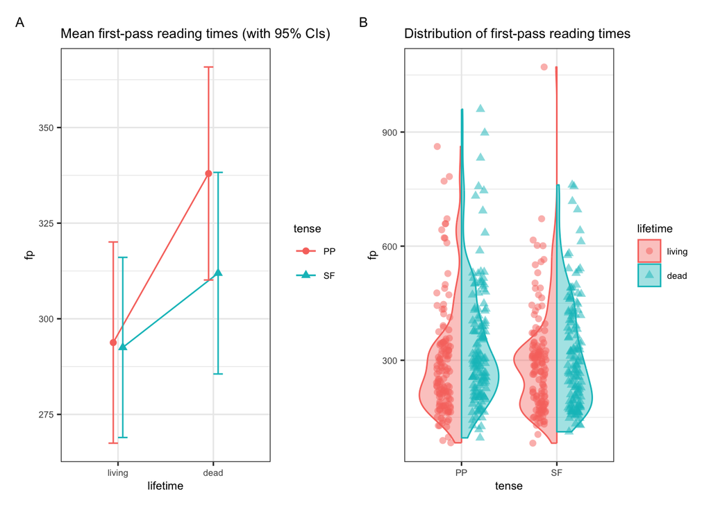

Figure 2: Plotting our two predictors

### 3.2.1 Plotting an interaction with `sjPlot`

```r
fig_sjplot_coef <- plot_model(fit_fp_inter) +
  geom_hline(yintercept=0) +
  theme_bw()

fig_sjplot_int <- plot_model(fit_fp_inter, type = "int") +
  geom_hline(yintercept=0) +
  geom_line(group=1) +
  theme_bw()
```

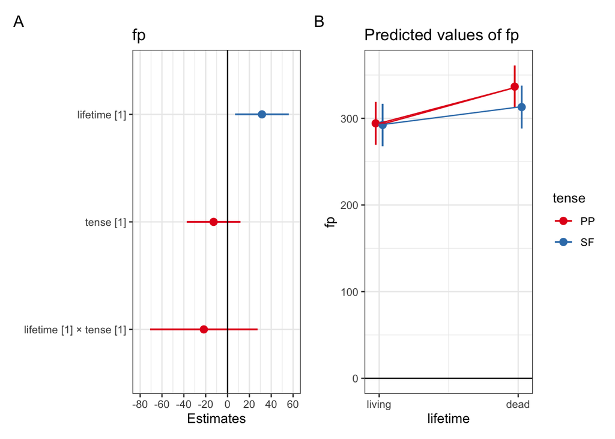

Figure 3: Plotting model coefficients (A) and interactions (B) with the sjPlot package

```r
fig_sjplot_coef + fig_sjplot_int + plot_annotation(tag_levels = "A")
```

# 4 Exercise

1.Run a model with main and interaction effects for `tense` and `lifetime` on `total reading time` at the `verb` region.

2. Print the summary and try to interpret it.
3. Plot the main and interaction effects, and the coefficients.

# References

McElreath, R. (n.d.). *Statistical Rethinking*.

Winter, B. (2019). *Statistics for Linguists: An Introduction Using R*. Routledge. https://doi.org/10.4324/9781315165547